# Time Series Homework: Chapter 2 Lesson 3 Key

## Data

```r
ind_prod <- rio::import("https://byuistats.github.io/timeseries/data/ind_prod_us.csv")
```

## Questions

### Question 1 - Context and Measurement (10 points)

The first part of any time series analysis is context. You cannot properly analyze data without knowing what the data is measuring. Without context, the most simple features of data can be obscure and inscrutable. This homework assignment will center around the series below.

Please research the time series. In the spaces below, give the data collection process, unit of analysis, and meaning of each observation for the series.

#### **Total US Industrial Production Index**

https://fred.stlouisfed.org/series/IPB50001N

**Answer**

**Description:** The Federal Reserve’s monthly index of industrial production and related capacity indexes and capacity utilization rates cover three major sectors: manufacturing, mining, and electric and gas utilities. Together with construction, these sectors account for the majority of the variation in national output over the course of the business cycle. The industrial production (IP) index measures the real output of relevant establishments located in the United States, regardless of their ownership, but does not include those located in U.S. territories.

The index provides detailed insights into structural developments within the economy. By capturing fluctuations in production across the industrial sector, the index helps illuminate broader trends and economic cycles, serving as a key indicator for assessing industrial activity in the U.S. economy.

**Data Collection Process:** The data is collected monthly by the Federal Reserve, which aggregates information from a variety of sources across the industrial sector. These sources include surveys, reports from utilities and manufacturing facilities, and mining production statistics. The process involves adjusting for real output changes rather than price variations, ensuring that the index reflects true production levels.

**Unit of Analysis:** The unit of analysis is an index where 2017 is set as the base year (2017 = 100). This standardization allows for comparison over time by indicating relative changes in industrial production since 2017. Each observation represents the level of production output for a given month as compared to the base year.

**Meaning of Each Observation:** Each monthly observation in the series reflects the aggregated real output of the U.S. industrial sector, encompassing manufacturing, mining, and utilities. The index value indicates how current production compares to the levels in 2017. For example, an index value of 105 means that industrial production is 5% higher than in 2017.

### Question 2 - Total US Industrial Production: Correlogram (20 points)

##### a) Please plot a correlogram of the US Industrial Production Index

**Answer**

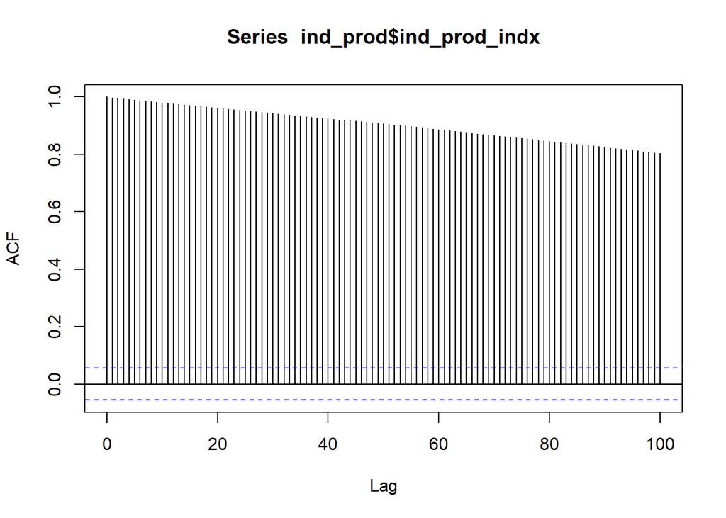

```r
acf(ind_prod$ind_prod_indx, plot=TRUE, type = "correlation", lag.max = 100)
```

##### b) Please identify evidence of any trend or seasonal component using the correlogram. Please justify your findings.

**Answer**

Based on the correlogram of the US Industrial Production Index, there is evidence of a trend due to the slow decline in autocorrelation values across many lags, indicating persistent relationships over time. The high autocorrelation values gradually decrease, which is typical of a trending series. However, there is no clear evidence of a seasonal pattern, as the autocorrelation function (ACF) does not show repeating spikes at regular intervals. Once the trend is removed, underlying seasonal patterns may be revealed.

### Question 3 - Total US Industrial Production: Decomposition (10 points)

##### a) Please plot a decomposition of the US Industrial Production Index series. Include the original series, trend, seasonal variation, and random component.

**Answer**

#### Additive

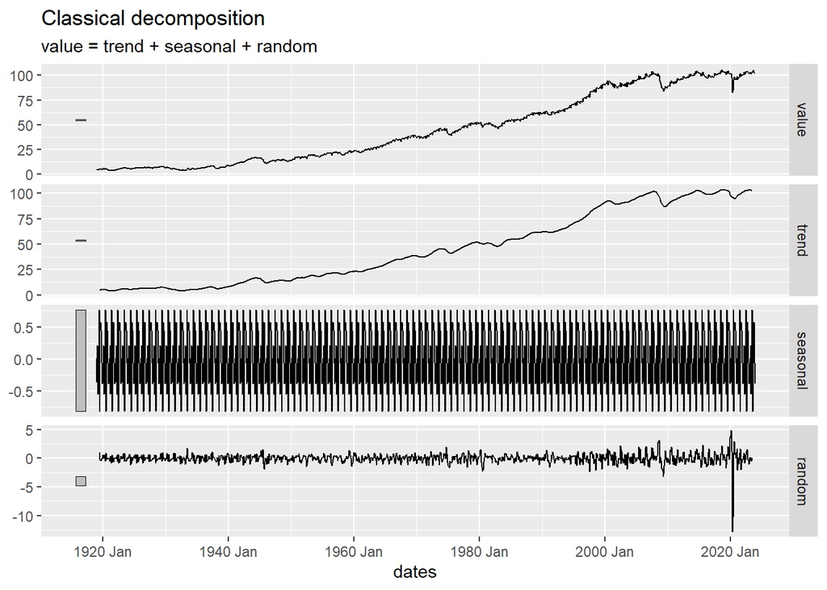

```r
ind_prod_ts <- rio::import("https://byuistats.github.io/timeseries/data/ind_prod_us.csv") |>
  mutate(
    dates = yearmonth(mdy(date)),
    value = ind_prod_indx
  ) |>
  dplyr::select(dates, value) |>
  as_tsibble(index = dates)
ind_prod_decompose <- ind_prod_ts |>
    model(feasts::classical_decomposition(value,
        type = "add"))  |>
    components()

autoplot(ind_prod_decompose)
```

#### Multiplicative

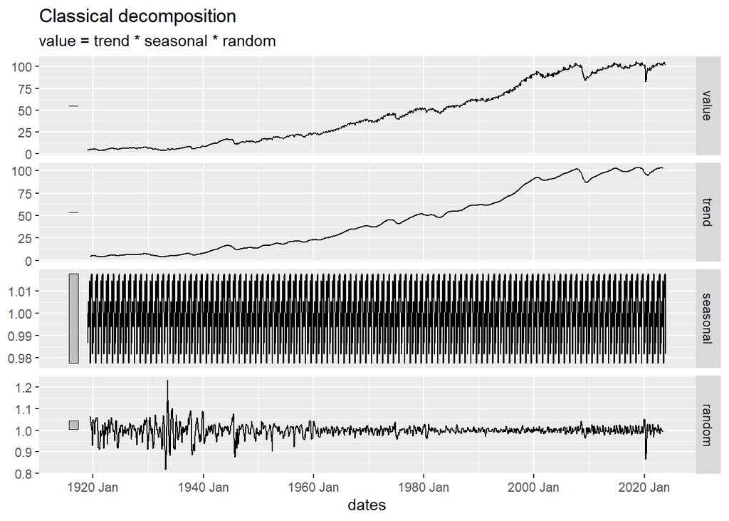

```r
ind_prod_decompose <- ind_prod_ts |>
    model(feasts::classical_decomposition(value,
        type = "multi"))  |>
    components()

autoplot(ind_prod_decompose)
```

### Question 4 - Total US Industrial Production: Stationary Series (20 points)

##### a) Please plot a correlogram of the random component of the US Industrial Production Index

**Answer**

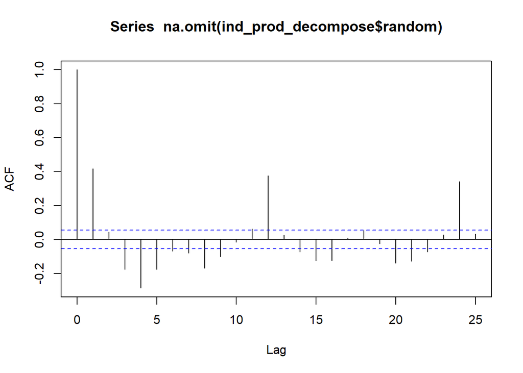

```r
# Step 1: Import the data and convert to time series format
ind_prod_ts <- rio::import("https://byuistats.github.io/timeseries/data/ind_prod_us.csv") |>
  mutate(
    dates = yearmonth(mdy(date)),
    value = ind_prod_indx
  ) |>
  dplyr::select(dates, value) |>
  as_tsibble(index = dates)

ind_prod_decompose <- ind_prod_ts |>
    model(feasts::classical_decomposition(value,
        type = "add"))  |>
    components()


acf(ind_prod_decompose$random |> na.omit(), plot=TRUE, type = "correlation", lag.max = 25)
```

### Question 5 - US Industrial Production Index: Introspection (20 points)

##### a) Why is it important to remove trend and seasonal variation before plotting and analyzing correlograms?

**Answer**

Removing trend and seasonal variation before analyzing correlograms is crucial because these patterns can mask underlying relationships and lead to spurious correlations. Trends and seasonality introduce strong autocorrelation at certain lags, overwhelming any subtle correlations in the underlying data. By removing these dominant patterns, we isolate the stationary component of the time series, allowing us to accurately assess the true relationships between data points at different lags and identify any remaining autocorrelation that might indicate the need for more complex modeling. This ensures that the analysis focuses on the underlying stochastic process rather than predictable cyclical fluctuations.

##### b) Please speculate on the importance of autocorrelation analysis of the random component of time series data on its modeling and investigation?

**Answer**

It is important and useful to do an analysis of the autocorrelation of the random component because it gives a good idea if our model needs adjusting, if the correct one is being used, and what is missing. The other components can mislead our interpretation. Trends, cause long persistent autocorrelation across many lags and, while seasonal variations create cyclical patterns that can change the underlying nature of the randomness. By removing these components to the best of our degree, it will better paint the picture of how the random component are independent (i.e., white noise) or if any remaining patterns need to be addressed in the model. This ensures that the analysis reflects true underlying relationships, rather than being influenced by predictable components like trend or seasonality.

### Rubric

[output not shown]